# Markdown Peer Assesment 1

Sebastian F Pinzon

7/29/2020

## Loading data

After extracting the zip file into the work directory, the following code was used to load the data in R.

```r
library(dplyr)
data=read.csv('activity.csv')
```

## Find daily mean and median of steps

The code below creates and histogram for total steps taken in a day and finds the mean and median daily steps. Missing values were ignored for the mean and median calculations:

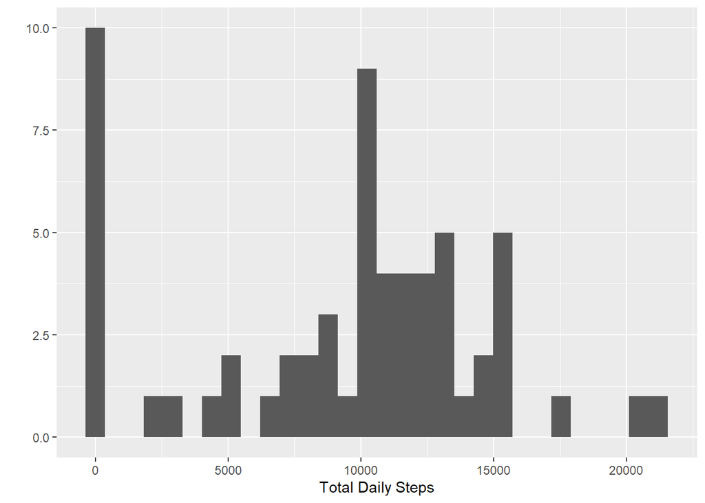

```r
library(ggplot2)
daily=data%>%group_by(date)%>%summarize(total=sum(steps, na.rm = T))
qplot(daily$total, geom="histogram", xlab="Total Daily Steps")
```

```r
mean=daily%>%summarize(mean=mean(total, na.rm=T))
median=daily%>%summarize(mean=median(total, na.rm=T))
```

The daily steps mean is 9354.2295082 and the median is 10395.

## Analyzing Activity per Interval

Code below creates a line plot for the average activity per time interval throughout the day and finds the interval with the most activity.

```r
interval=data%>%group_by(interval)%>%summarize(mean=mean(steps,na.rm=T))
```

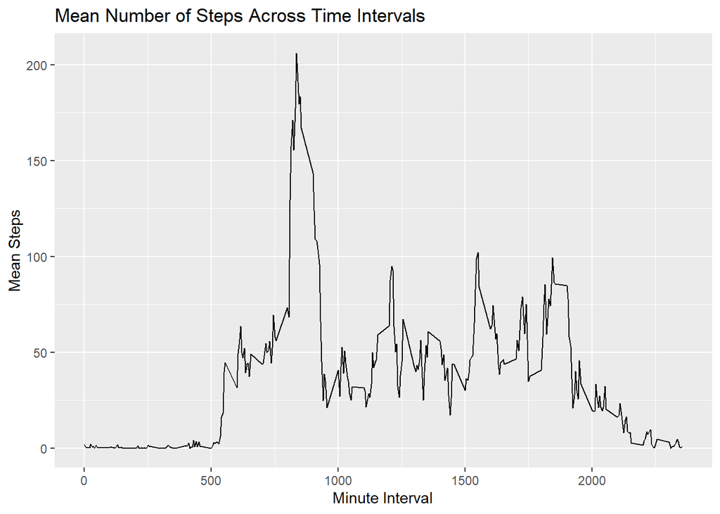

```r
qplot(interval$interval, interval$mean, geom="line", xlab="Minute Interval",
      ylab="Mean Steps", main = "Mean Number of Steps Across Time Intervals")
```

```r
maxint=interval%>%filter(mean==max(mean))
```

The interval with the most activity is 835.

## Handling missing values

```r
nas=sum(is.na(data$steps))
data2=merge(data, interval)
meanrep=data2$mean[is.na(data2$steps)]
data2$steps=replace(data2$steps,is.na(data2$steps),meanrep)
daily2=data2%>%group_by(date)%>%summarize(total=sum(steps))
```

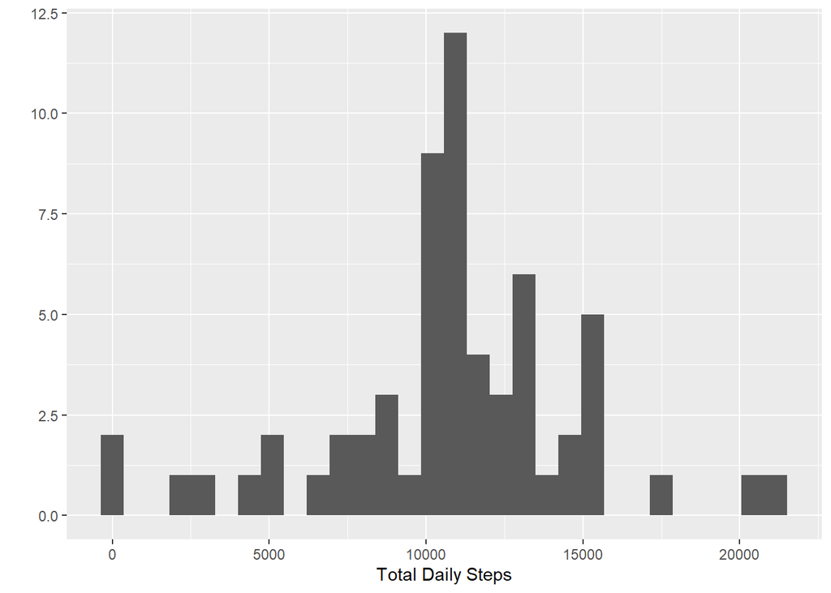

```r
qplot(daily2$total, geom="histogram", xlab="Total Daily Steps")
```

```r
mean2=daily%>%summarize(mean=mean(total))
median2=daily%>%summarize(mean=median(total))
```

## Weekly Patterns

The code below creates a factor variable to label days as weekdays or weekend. Then, it creates a new data frame where the average steps in a time interval is calculated for weekdays and weekend days. The plot below shows the activity pattern change between the two periods.

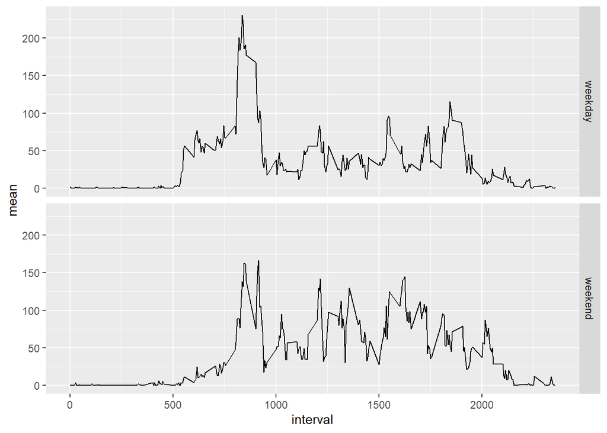

```r
data2=data2[order(data2$date,data2$interval),]
data2$day=weekdays(as.Date(data2$date))
data2$week=as.factor(ifelse(data2$day=="Saturday"|data2$day=="Sunday", "weekend", "weekday"))
dfplot=data2%>%group_by(week,interval)%>%summarize(mean=mean(steps))
g<-ggplot(dfplot, aes(interval,mean))+geom_line()
g+facet_grid(rows=vars(week))
```